# 통계밥법론2 Chap8 실습코드

202140191 엄태훈

2021-11-06(SAT)

# Chap8 Models for Polytomous Responses

Chapter7에서 우리는 binary response에 대해서 알아보았다.  
Chapter8에서는 **binary**가 아닌 **다중 범주를 갖고있는 반응 변수**를 처리하기위한 방법들에 대해서 알아본다.

또한, 범주형 변수의 경우 명목형 변수인지 순서형 변수인지로 나누게 되는데, 변수가 명목형 변수일때와 순서형 변수일 때 서로 다른 모형을 사용할 수 있게 되므로 어떠한 모형을 적용할 수 있는지에 대해서도 알아본다.

일반적으로 다중 반응 변수는 범주형 변수의 수준이 3개 이상인 경우를 말한다.  
EX)

- 환자의 약 복용효과: “Marked”, “Some”, “None”
- 학생들의 교육수준: “Middle school”, “High school”, “University”
- 대한민국 성인의 소득수준: “low”, “Middle”, “High”

다중 반응 확률을 모형화하는 방법 중 하나는 예측변수가 주어졌을 때, **그룹에 대한 반응 확률**을 구한 후, 반응에 대한 모형을 설명 변수에서 요인을 처리하는 방법과 유사한 방식으로 구성하는 것이다.

## 8.1 Ordinal response: Proportional odds model

가장 간단한 방법은 **Proportional odds model**이다. 이 모델은 반응변수가 순서형 변수이고 **proportional odds assumptions**이 성립할 때 사용이 가능하다.  
**proportional odds assumptions**은 모형에 포함된 각 항에 대해 반응변수들의 수준에서 결과의 각 쌍 사이의 **기울기** 추정치는 우리가 고려한 분할에 관계없이 동일하다고 가정하는 것이다.  
즉, **Proportional odds model**의 설명 변수(x)는 모든 누적logit에 대해 **동일한 기울기**를 갖도록 제한된다.

반응변수 Y의 수준이 순서형인 경우, 연속적인 범주 사이의 인접 범주 컷포인트에 기초한 로짓을 통해 순서적 특성을 고려할 수 있다.

### 8.1.1 Latent variable Interpretation

이항 반응 변수의 경우, 로지스틱 회귀에 대해서 관측된 Y의 관계를 실패가 아닌 성공의 성향을 나타내면, (잠재적) 관측되지 않은 연속 반응 변수에서 발생한다고 간주한다.  
**잠재 반응**은 예측 변수 x와 선형적으로 관련이 있다고 가정하지만, 그 잠재반응이 특정 임계값을 지날 때 볼 수 있으며, 일부 편리한 스케일링을 통해 모델에 따른 순서형 반응으로 직접 확장될 수 있다.

### 8.1.2 Fitting the proportional odds model

R에서는 `MASS`패키지의 `polr`함수를 통해 **proportional odds model**을 만들 수 있다.  
`polr`함수는 **로지스틱** 또는 **프로빗(정규분포의 누적확률의 역확률) 회귀모형**을 순서가 지정된 요인 반응변수에 대해 적합시키는 함수이다.  
반응 변수에 숫자값이 없는 경우, 반응 변수가 순서형인지 명목형인지 확인하는 것이 중요하다.  
- `polr(,data)`

- formula: 분석가가 만들고자 하는 모델의 형태
- data: 모델 구성에 사용할 데이터

```r
data("Arthritis", package = "vcd")
head(Arthritis$Improved, 8)
```

```
## [1] Some   None   None   Marked Marked Marked None   Marked
## Levels: None < Some < Marked
```

`Arthritis` 데이터셋의 반응변수 `Improved`는 수준이 None - Some - Marked의 순서로 이루어진 순서형 변수이다.

```r
library(MASS)
arth.polr <- polr(Improved ~ Sex + Treatment + Age,
                  data = Arthritis, Hess = TRUE)
summary(arth.polr)
```

```
## Call:
## polr(formula = Improved ~ Sex + Treatment + Age, data = Arthritis,
##     Hess = TRUE)
##
## Coefficients:
##                     Value Std. Error t value
## SexMale          -1.25168    0.54636  -2.291
## TreatmentTreated  1.74529    0.47589   3.667
## Age               0.03816    0.01842   2.072
##
## Intercepts:
##             Value   Std. Error t value
## None|Some    2.5319  1.0571     2.3952
## Some|Marked  3.4309  1.0912     3.1443
##
## Residual Deviance: 145.4579
## AIC: 155.4579
```

순서형 반응변수에 대해 설명변수 **Sex, Treatment, Age**를 이용하여 `polr`함수를 통해 **proportional odds model**을 적용한 결과이다.  
독립변수들의 계수, 표준오차, t value등을 제공하며, 반응변수간 순서에 따른 Intercepts도 확인이 가능하다.

```r
library(car)
Anova(arth.polr)
```

```
## Analysis of Deviance Table (Type II tests)
##
## Response: Improved
##           LR Chisq Df Pr(>Chisq)
## Sex         5.6880  1  0.0170812 *
## Treatment  14.7095  1  0.0001254 ***
## Age         4.5715  1  0.0325081 *
## ---
## Signif. codes:  0 '***' 0.001 '**' 0.01 '*' 0.05 '.' 0.1 ' ' 1
```

단, `polr` 함수의의 결과는 유의확률을 유의성 검정을 제공하지 않으므로, `car`패키지의 `Anova`함수를 통해 설명변수들의 유의성 검정을 진행한다.  
설명변수 **Sex, Treatment, Age**의 유의확률이 유의수준 0.05보다 작으므로 모두 유의한 설명변수인 것을 확인할 수 있다.

### 8.1.3 Testing the proportional odds assumption

**proportional odds model**은 지정된 데이터 집합에 대해 유지되는 경우에만 달성된다.  
본질적으로 이 가정애 대한 검정에는 **proportional odds model**과 반응 범주 전체에 걸쳐 설명변수의 서로 다른 효과를 허용하는 일반화된 로짓 **NPO** 모델 간의 대조가 수반된다. 가장 일반적인 검정은 두 모형을 모두 적합시키고 우도비 검정을 통해 모형을 비교하는 것이다.

**partial proportional odds model**은 예측 변수의 한 부분 집합이 **proportional odds assumptions**을 만족하도록 허용하고 나머지 설명변수 X의 **NPO**는 반응 변수수준에 따라 기울기가 달라진다.

R에서 PO와 NPO모델은 `VGAM`패키지의 `vglm`함수를 사용하여 둘 다 적합시킴으로써 쉽게 대조할 수 있다.  
`VGAM`패키지는 `glm`방법중에서도 다변량의 데이터를 고려하여 통계적 회귀 모델을 도출해야하는 경우, 유용하게 사용할 수 있는 패키지이다.  
`vglm`함수는 벡터 일반화 선형 모형을 적합시키는 모델로 일반적으로 클래스가 매우 많은 모델에 대하여 특별한 `glm`을 적합시키고자 할때 사용한다.  
- `vglm(,data)`

- : 분석가가 만들고자 하는 모델의 형태
- data: 모델 구성에 사용할 데이터

```r
library(VGAM)
arth.po <- vglm(Improved ~ Sex + Treatment + Age, data = Arthritis, family = cumulative(parallel = TRUE))
arth.po
```

```
##
## Call:
## vglm(formula = Improved ~ Sex + Treatment + Age, family = cumulative(parallel = TRUE),
##     data = Arthritis)
##
##
## Coefficients:
##    (Intercept):1    (Intercept):2          SexMale TreatmentTreated
##       2.53199006       3.43098785       1.25167130      -1.74530408
##              Age
##      -0.03816279
##
## Degrees of Freedom: 168 Total; 163 Residual
## Residual deviance: 145.4579
## Log-likelihood: -72.72896
```

**po모델**의 경우, `parallel = TRUE`로 지정한다.  
**po모델**은 반응변수의 모든 누적 로짓 확률에 대해서 동일한 기울기를 같게하므로, 절편을 제외하고 모두 동일한 기울기가 출력되는 것을 확인할 수 있다.

```r
arth.npo <- vglm(Improved ~ Sex + Treatment + Age, data = Arthritis, family = cumulative(parallel = FALSE))
arth.npo
```

```
##
## Call:
## vglm(formula = Improved ~ Sex + Treatment + Age, family = cumulative(parallel = FALSE),
##     data = Arthritis)
##
##
## Coefficients:
##      (Intercept):1      (Intercept):2          SexMale:1          SexMale:2
##         2.61853875         3.43117450         1.50982704         0.86643395
## TreatmentTreated:1 TreatmentTreated:2              Age:1              Age:2
##        -1.83692928        -1.70401146        -0.04086648        -0.03729421
##
## Degrees of Freedom: 168 Total; 160 Residual
## Residual deviance: 143.5741
## Log-likelihood: -71.78703
```

**npo모델**의 경우, `parallel = FALSE`을 옵션을 추가하여 적합시킬 수 있다.  
**npo모델**은 반응변수에 대해 설명변수들의 다른 효과를 허용하게 되므로, **po**모델과 달리 절편을 포함하여 다른 모든 설명변수들이 반응변수의 수준에 따라 다른 기울기를 갖고있는 것을 알 수 있다.

```r
coef(arth.po, matrix = TRUE)
```

```
##                  logitlink(P[Y<=1]) logitlink(P[Y<=2])
## (Intercept)              2.53199006         3.43098785
## SexMale                  1.25167130         1.25167130
## TreatmentTreated        -1.74530408        -1.74530408
## Age                     -0.03816279        -0.03816279
```

```r
coef(arth.npo, matrix = TRUE)
```

```
##                  logitlink(P[Y<=1]) logitlink(P[Y<=2])
## (Intercept)              2.61853875         3.43117450
## SexMale                  1.50982704         0.86643395
## TreatmentTreated        -1.83692928        -1.70401146
## Age                     -0.04086648        -0.03729421
```

`coef`를 통해 각 누적 로짓 확률에 대한 대한 변수들의 계수를 살펴볼 수 있다.  
**po**모델의 경우, 누적 로짓 확률이 변해도 동일한 기울기를 갖지만, **npo**모델의 경우, 누적 로짓 확률이 변하면 기울기가 달라지는 것을 확인할 수 있다.

```r
VGAM::lrtest(arth.npo, arth.po)
```

```
## Likelihood ratio test
##
## Model 1: Improved ~ Sex + Treatment + Age
## Model 2: Improved ~ Sex + Treatment + Age
##   #Df  LogLik Df  Chisq Pr(>Chisq)
## 1 160 -71.787
## 2 163 -72.729  3 1.8838     0.5969
```

모형에 대한 우도비 검정 결과, 유의확률은 유의수준 0.05보다 크므로 귀무가설을 기각하지 못한다.  
따라서, **두 모형(po모델, np모델)**간 차이가 없는 것을 알 수 있다.

```r
tab <- cbind(
  Deviance = c(deviance(arth.npo), deviance(arth.po)),
  df = c(df.residual(arth.npo), df.residual(arth.po))
)
tab <- rbind(tab, diff(tab))
rownames(tab) <- c("GenLogit", "PropOdds", "LR test")
tab <- cbind(tab, pvalue = 1 - pchisq(tab[,1], tab[,2]))
tab
```

```
##            Deviance  df    pvalue
## GenLogit 143.574067 160 0.8196626
## PropOdds 145.457915 163 0.8343527
## LR test    1.883849   3 0.5968607
```

두 모델의 **Deviance** 비교를 통해서도 모델의 적합도를 확인할 수 있다.  
모델의 잔차 차이는 1.88로 크지않고 유의확률 또한 유의수준 0.05보다 크므로 귀무가설을 기각하지 못한다.  
따라서, 두 모델간 유의한 잔차의 차이는 존재하지 않는 것을 알 수 있다.

```r
arth.ppo <- vglm(Improved ~ Sex + Treatment + Age,
                 data = Arthritis, family = cumulative(parallel =  FALSE ~ Sex))
coef(arth.ppo, matrix = TRUE)
```

```
##                  logitlink(P[Y<=1]) logitlink(P[Y<=2])
## (Intercept)              2.54245216         3.61556073
## SexMale                  1.48333554         0.86736192
## TreatmentTreated        -1.77574178        -1.77574178
## Age                     -0.03962233        -0.03962233
```

`vglm`은 또한 partial **proportional odds model**을 만들 수 있다.  
`Arthritis` 데이터에서 **Sex**변수를 제외한 나머지 변수는 병렬을 가정하고, **Sex**변수는 병렬을 가정하지 않았다.  
그 결과, **Sex**변수는 로짓의 누적 확률에 따라 기울기가 다르지만 **Treatment, Age**변수는 로짓의 누적 확률에 따라 기울기가 동일한 것을 확인할 수 있다.

### 8.1.4 Graphical assessment of proportional oods

**proportional odds assumption**를 시각적으로 평가하기 위한 다양한 그래픽 방법이 있다.  
한 가지 아이디어는 반응 변수 Y의 수준에서 주어진 예측 변수 X의 기대값을 표시하는 것이다.

```r
library(rms)
arth.po2 <- lrm(Improved ~ Sex + Treatment + Age, data = Arthritis)
arth.po2
```

```
## Logistic Regression Model
##
##  lrm(formula = Improved ~ Sex + Treatment + Age, data = Arthritis)
##
##                         Model Likelihood    Discrimination    Rank Discrim.
##                               Ratio Test           Indexes          Indexes
##  Obs            84    LR chi2      24.46    R2       0.291    C       0.750
##   None          42    d.f.             3    g        1.335    Dxy     0.500
##   Some          14    Pr(> chi2) <0.0001    gr       3.801    gamma   0.503
##   Marked        28                          gp       0.280    tau-a   0.309
##  max |deriv| 1e-07                          Brier    0.187
##
##                    Coef    S.E.   Wald Z Pr(>|Z|)
##  y>=Some           -2.5320 1.0570 -2.40  0.0166
##  y>=Marked         -3.4310 1.0911 -3.14  0.0017
##  Sex=Male          -1.2517 0.5464 -2.29  0.0220
##  Treatment=Treated  1.7453 0.4759  3.67  0.0002
##  Age                0.0382 0.0184  2.07  0.0382
##
```

Chapter7에서 살펴본 `lrm`함수를 통해 모형을 적합시키고, 모형에 대한 다양한 시각화를 진행할 수 있다.

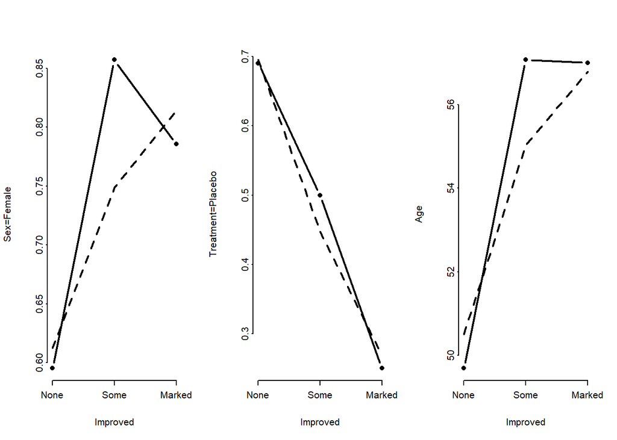

```r
op <- par(mfrow=c(1,3))
plot.xmean.ordinaly(Improved ~ Sex + Treatment + Age,
                    data = Arthritis,
                    lwd = 2, pch = 16, subn = FALSE)
```

`rms` 패키지의 `plot.xmean.ordinaly`을 통해 반응 변수 수준에 따른 X의 기대값을 확인할 수 있다.  
`plot.xmean,ordinaly(,data)`

- : 시각화를 진행할 식 (일반적으로 반응변수 ~ 독립변수 + 독립변수..)
- data:: 식에 사용되는 데이터

**실선**은 X가 주어졌을 때 Y의 계층화된 평균을 연결하고 **점선**은 X에 대해 **비례 승산 모델**이 유지되는 경우의 Y의 기대값을 나타낸다.  
**비례 승산 모델**의 기울기는 일반적으로 완만한 것을 볼 수 있다.

### 8.1.5 Visualizing result for the proportioanl odds model

앞에서 살펴본 비슷한 아이디어를 통해 **PO**모델의 결과 또한 시각적으로 표현할 수 있다.  
여기서, Chapter7에서 배운 `effect plots`는 여전히 유용하게 사용할 수 있는 함수이다.

#### 8.1.5.1 Full-model plots

```r
arth.fitp <- cbind(Arthritis,
                   predict(arth.polr, type = "probs"))
head(arth.fitp)
```

```
##   ID Treatment  Sex Age Improved      None      Some    Marked
## 1 57   Treated Male  27     Some 0.7326185 0.1380586 0.1293229
## 2 46   Treated Male  29     None 0.7174048 0.1444325 0.1381627
## 3 77   Treated Male  30     None 0.7096042 0.1476259 0.1427699
## 4 17   Treated Male  32   Marked 0.6936286 0.1540035 0.1523679
## 5 36   Treated Male  46   Marked 0.5702499 0.1950359 0.2347142
## 6 23   Treated Male  58   Marked 0.4563432 0.2171302 0.3265266
```

적합시킨 모델 `arth.polr`을 이용하여 각 데이터가 주어졌을 때, 순서형 반응변수에 대한 예측 확률값을 `predict`함수를 이용하여 구하였다.

```r
library(reshape2)
plotdat <- melt(arth.fitp,
                id.vars = c("Sex","Treatment","Age","Improved"),
                measure.vars = c("None","Some","Marked"),
                variable.name = "Level",
                value.name = "Probability")
head(plotdat,5)
```

```
##    Sex Treatment Age Improved Level Probability
## 1 Male   Treated  27     Some  None   0.7326185
## 2 Male   Treated  29     None  None   0.7174048
## 3 Male   Treated  30     None  None   0.7096042
## 4 Male   Treated  32   Marked  None   0.6936286
## 5 Male   Treated  46   Marked  None   0.5702499
```

`melt`함수를 이용하여 시각화를 진행하기 유용한 데이터의 형태로 바꿔주었다.

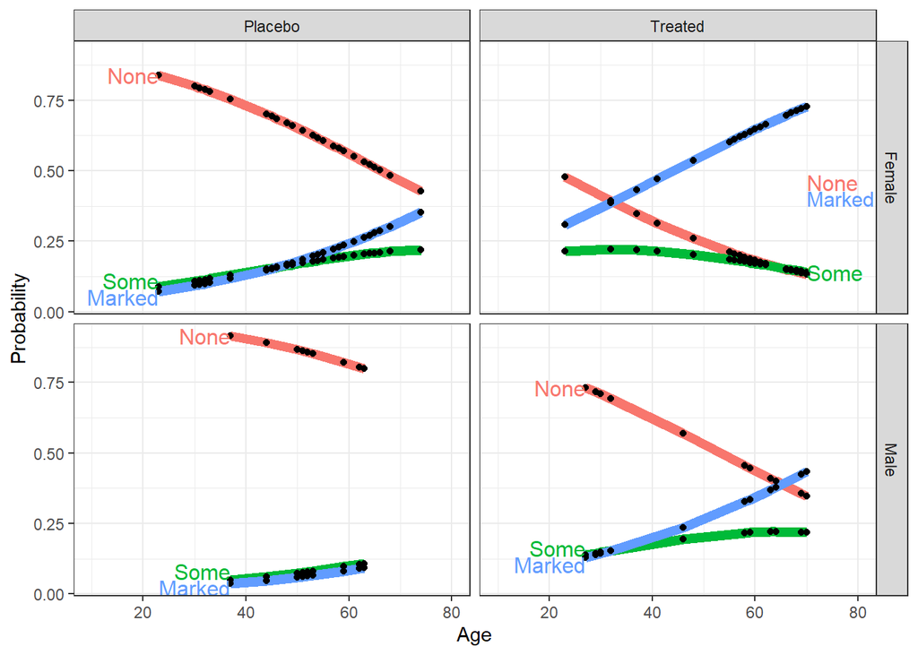

```r
library(ggplot2)
library(directlabels)
gg <- ggplot(plotdat, aes(x = Age, y = Probability, colour = Level)) +
  geom_line(size = 2.5) + theme_bw() + xlim(10,80) +
  geom_point(color = "black", size = 1.5) +
  facet_grid(Sex ~ Treatment,
  )
direct.label(gg)
```

**여성**과 **남성**의 경우, **Treated** 그룹에서 나이가 증가함에 따라 **Improved = Marked**일 확률이 높아지는 것을 확인할 수 있고 **Improved = None**일 확률이 감소하는 것을 알 수 있다.  
**Placebo**그룹에서도 나이가 증가함에따라 **Improved = None**일 확률이 줄어들고 **Improved = Some,Marked**일 확률이 증가하는것을 확인할 수 있다.  
하지만, **Treated**그룹에 비해 **Improved = None**일 확률이 매우 높고 **Improved = Marked**일 확률이 매우 낮은 것을 확인할 수 있다.

### 8.1.5.2 Effect plots

`effects`패키지를 통해 그려지는 곡선은 예측 확률에 대한 지정된 효과의 서로 다른 반응 수준에 대해 표시해준다.

```r
library(effects)
```

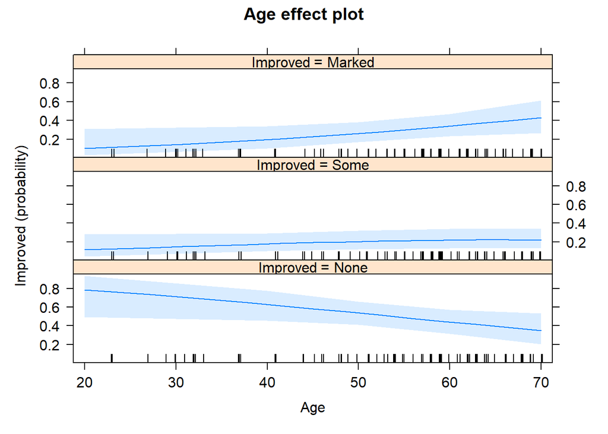

```r
plot(Effect("Age",arth.polr))
```

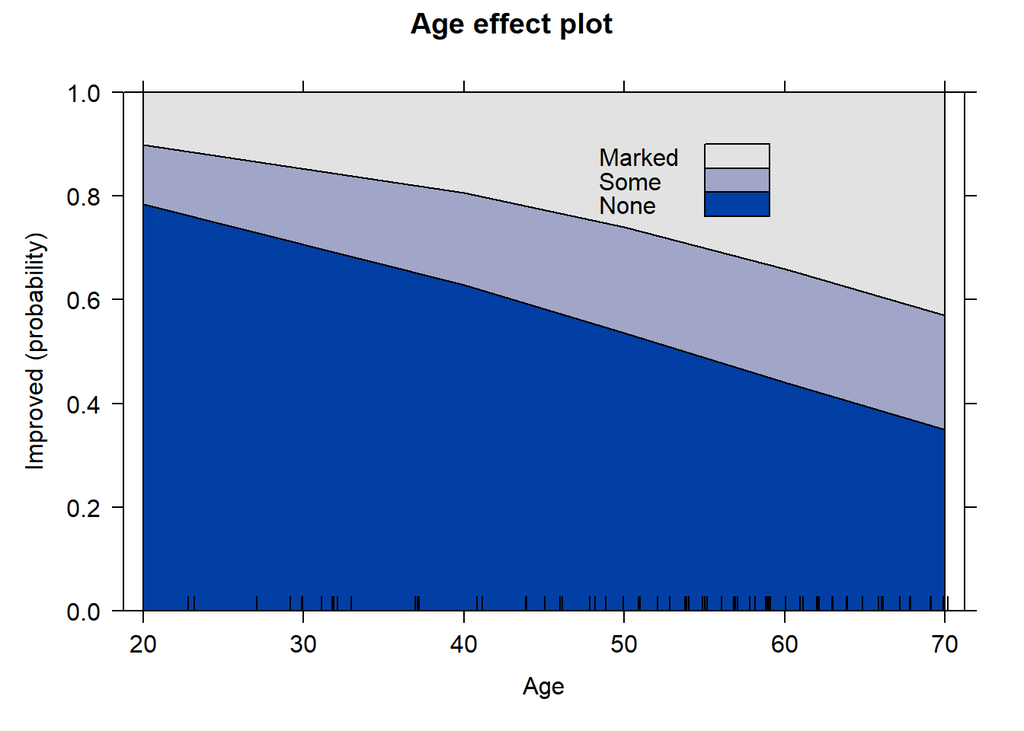

```r
plot(Effect("Age",arth.polr),style = "stacked",
     key.args = list(x = .55, y = .9))
```

기본적인 **Age effect plot**과 **Stacked plot**을 통해 나이가 증가함에 따라, **Improved = Marked**일 확률이 높아지고, **Improved = None**일 확률이 줄어드는 것을 확인할 수 있다.

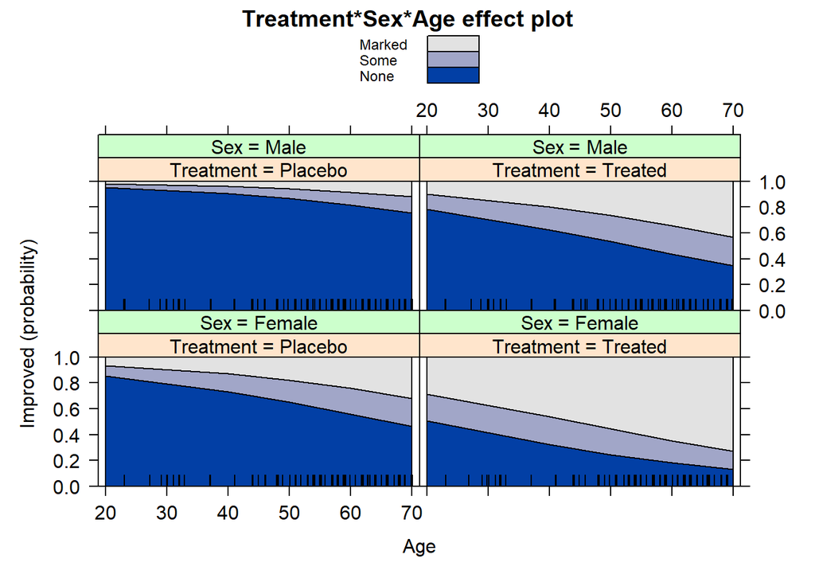

```r
plot(Effect(c("Treatment","Sex","Age"),arth.polr),
     style = "stacked",key.arg = list(x = .8, y = .9))
```

**Treatment = Placebo**그룹의 경우 **Improved = None**이 차지하는 확률이 높지만, **Treatment = Treated**그룹의 경우 **Improved = Marked 또는 Some**이 차지하는 확률이 높고 **Improved = None**이 차지하는 확률이 작은 것을 확인할 수 있다.

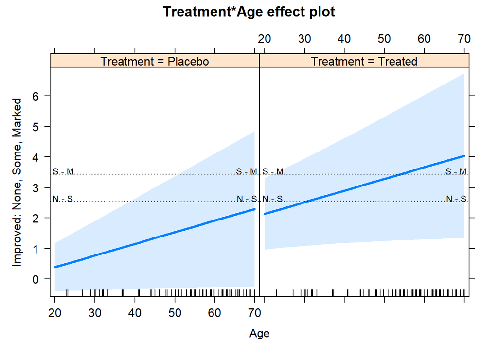

```r
plot(Effect(c("Treatment","Age"),
            arth.polr,latent = TRUE), lwd = 3)
```

`latent = TRUE`옵션을 지정하게 되면 각 반응변수의 수준으로 분류될 수 있는 기준점을 보여주고 각 그룹에 대하여 `Effect plot`중 변화가 가장 뚜렷한 **plot**만을 패널에 출력한다.

## 8.2 Nested dichotomies

반응 변수가 명목형인 경우 혹은 **proportional odds assumptions**이 성립하지 않는다. 따라서, **nested dichotomies**이라는 모형을 사용하게 되는데, 이 방법을 사용하면 반응변수의 수준간의 차이를 분산 분석의 직교대비처럼 확인할 수 있다.  
이 방법에는 순서형 반응변수나 특별한 소프트웨어가 필요하지 않으며, 반응 범주 간의 계층적으로 내포된 비교 집합에 대해 개별 모형을 적합시킨다.(독립가정)

*Example 8.1: Women’s labor force participation*

```r
library(car)
data("Womenlf", package = "car")
some(Womenlf)
```

```
##       partic hincome children  region
## 31  not.work      13  present Ontario
## 66  not.work      15  present Ontario
## 124 fulltime       9   absent Ontario
## 134 fulltime      14   absent Ontario
## 141 not.work      14  present Ontario
## 167 not.work      15  present Ontario
## 170 parttime       8  present      BC
## 216 parttime      17  present  Quebec
## 221 not.work       5   absent  Quebec
## 244 fulltime       6  present  Quebec
```

`womenlf`데이터는 1977년 캐나다의 인구조사에 따른 데이터이며, 여성의 생활에 관련된 정보를 담고있다.  
`womenlf`데이터는 `car`패키지에 포함돼있다.

- partic: 여성의 노동력 참여 (Factor variable - fulltime, nt.work, parttime)
- hincome: 남편의 수입 <기준은 1000달러> (discrete variable)
- children: 아이의 유무 (Factor variable - absent, present)
- region: 지역 (Factor variable - Atlantic, BC, Ontario, Prairie, Quebec)

```r
Womenlf <- within(Womenlf,{
  working <- recode(partic, " 'not.work' = 'no'; else = 'yes' ")
  fulltime <- recode(partic,
                     " 'fulltime' = 'yes'; 'parttime' = 'no'; 'not.work' = NA")})
some(Womenlf)
```

```
##       partic hincome children  region fulltime working
## 20  not.work      13   absent Ontario     <NA>      no
## 28  not.work      19  present Ontario     <NA>      no
## 116 not.work      13  present Prairie     <NA>      no
## 126 parttime      13  present Ontario       no     yes
## 131 parttime      19  present Ontario       no     yes
## 167 not.work      15  present Ontario     <NA>      no
## 190 not.work      23  present      BC     <NA>      no
## 200 fulltime      11   absent  Quebec      yes     yes
## 215 not.work      15  present  Quebec     <NA>      no
## 230 parttime      23  present  Quebec       no     yes
```

```r
with(Womenlf, table(partic, working))
```

```
##           working
## partic      no yes
##   fulltime   0  66
##   not.work 155   0
##   parttime   0  42
```

```r
with(Womenlf, table(partic, fulltime, useNA = "ifany"))
```

```
##           fulltime
## partic      no yes <NA>
##   fulltime   0  66    0
##   not.work   0   0  155
##   parttime  42   0    0
```

`Womenlf`데이터에 대해서 `recode`함수를 이용하여 연구자가 원하는 형태로 범주를 재구성하여 데이터에 대한 전처리를 진행한다.

```r
mod.working <- glm(working ~ hincome + children, family = binomial, data = Womenlf)
summary(mod.working)
```

```
##
## Call:
## glm(formula = working ~ hincome + children, family = binomial,
##     data = Womenlf)
##
## Deviance Residuals:
##     Min       1Q   Median       3Q      Max
## -1.6767  -0.8652  -0.7768   0.9292   1.9970
##
## Coefficients:
##                 Estimate Std. Error z value Pr(>|z|)
## (Intercept)      1.33583    0.38376   3.481   0.0005 ***
## hincome         -0.04231    0.01978  -2.139   0.0324 *
## childrenpresent -1.57565    0.29226  -5.391    7e-08 ***
## ---
## Signif. codes:  0 '***' 0.001 '**' 0.01 '*' 0.05 '.' 0.1 ' ' 1
##
## (Dispersion parameter for binomial family taken to be 1)
##
##     Null deviance: 356.15  on 262  degrees of freedom
## Residual deviance: 319.73  on 260  degrees of freedom
## AIC: 325.73
##
## Number of Fisher Scoring iterations: 4
```

일을하는 여성과 일을하지 않는 여성만으로 나눈 `working`을 반응변수로 하여 **로지스틱 회귀 모형**을 적합시켜 보았다.  
설명변수 **hincome, children**모두 유의확률이 유의수준 0.05보다 작으므로 유의한 설명변수인 것을 확인할 수 있다.

```r
mod.fulltime <- glm(fulltime ~ hincome + children, family = binomial, data = Womenlf)
summary(mod.fulltime)
```

```
##
## Call:
## glm(formula = fulltime ~ hincome + children, family = binomial,
##     data = Womenlf)
##
## Deviance Residuals:
##     Min       1Q   Median       3Q      Max
## -2.4047  -0.8678   0.3949   0.6213   1.7641
##
## Coefficients:
##                 Estimate Std. Error z value Pr(>|z|)
## (Intercept)      3.47777    0.76711   4.534 5.80e-06 ***
## hincome         -0.10727    0.03915  -2.740  0.00615 **
## childrenpresent -2.65146    0.54108  -4.900 9.57e-07 ***
## ---
## Signif. codes:  0 '***' 0.001 '**' 0.01 '*' 0.05 '.' 0.1 ' ' 1
##
## (Dispersion parameter for binomial family taken to be 1)
##
##     Null deviance: 144.34  on 107  degrees of freedom
## Residual deviance: 104.49  on 105  degrees of freedom
##   (결측으로 인하여 155개의 관측치가 삭제되었습니다.)
## AIC: 110.49
##
## Number of Fisher Scoring iterations: 5
```

일을하지 않는 여성은 결측값으로하고 알바를 할경우 **No** 정규직의 경우에는 **Yes**로 재코딩을한 변수인 `fulltime`을 반응변수로 하여 다시 한 번 로지스틱 회귀모형을 적합시켜 보았다.  
`mod.working` 모델과 같이 **hincome, children**모두 유의확률이 유의수준 0.05보다 작으므로 유의한 설명변수임을 확인할 수 있다.

```r
cbind(working = coef(mod.working), fulltime = coef(mod.fulltime))
```

```
##                     working   fulltime
## (Intercept)      1.33582979  3.4777735
## hincome         -0.04230843 -0.1072679
## childrenpresent -1.57564843 -2.6514557
```

적합시킨 두 모형에 대한 계수를 확인해본 결과, **hincome, children** 모두 계수가 음수이므로 여성의 근로 선택에 대해서 로짓 확률을 감소 시키는 변수임을 확인할 수 있다.

```r
LRtest <- function(model){
  c(LRchisq = model$null.deviance - model$deviance,
    df = model$df.null - model$df.residual)
}
tab <- rbind(working = LRtest(mod.working),
             fulltime = LRtest(mod.fulltime))
tab <- rbind(tab, All = colSums(tab))
tab <- cbind(tab, pvalue = 1 - pchisq(tab[,1], tab[,2]))
tab
```

```
##           LRchisq df       pvalue
## working  36.41835  2 1.235536e-08
## fulltime 39.84682  2 2.225215e-09
## All      76.26518  4 1.110223e-15
```

```r
Anova(mod.working)
```

```
## Analysis of Deviance Table (Type II tests)
##
## Response: working
##          LR Chisq Df Pr(>Chisq)
## hincome    4.8264  1    0.02803 *
## children  31.3229  1  2.185e-08 ***
## ---
## Signif. codes:  0 '***' 0.001 '**' 0.01 '*' 0.05 '.' 0.1 ' ' 1
```

```r
Anova(mod.fulltime)
```

```
## Analysis of Deviance Table (Type II tests)
##
## Response: fulltime
##          LR Chisq Df Pr(>Chisq)
## hincome     8.981  1   0.002728 **
## children   32.136  1  1.437e-08 ***
## ---
## Signif. codes:  0 '***' 0.001 '**' 0.01 '*' 0.05 '.' 0.1 ' ' 1
```

`Anova`함수를 통해 개별 설명변수에 대한 검정을 진행할 수 있다.  
두 모델의 **hincome**변수를 살펴보면, 카이제곱 검정통계량은 4.826 + 8.981 = 13.807이고 자유도는 2이다.  
이러한 통계치를 통해 설명변수의 적합 여부를 확인할 수 있다.

```r
predictors <- expand.grid(hincome = 1:50,
                          children = c('absent', 'present'))
fit <- data.frame(predictors,
                  p.working = predict(mod.working,predictors,type = "response"),
                  p.fulltime = predict(mod.fulltime,predictors, type = "response"),
                  l.working = predict(mod.working,predictors,type = "link"),
                  l.fulltime = predict(mod.fulltime,predictors, type = "link"))
print(some(fit,5), digits = 3)
```

```
##    hincome children p.working p.fulltime l.working l.fulltime
## 8        8   absent     0.731     0.9321     0.997      2.620
## 34      34   absent     0.474     0.4578    -0.103     -0.169
## 35      35   absent     0.464     0.4313    -0.145     -0.277
## 81      31  present     0.175     0.0759    -1.551     -2.499
## 90      40  present     0.127     0.0303    -1.932     -3.464
```

`predict`를 통해 만들어진 모델을 이용하여 새로운 데이터에 대한 예측을 진행한다.  
`type = response`는 예측에 대한 확률 값을 제공해주며, `type = link`는 독립변수들의 선형 모델 결과(log-odds)를 출력해준다.

```r
fit <- within(fit, {
  'full-time' <- p.working * p.fulltime
  'part-time' <- p.working * (1 - p.fulltime)
  'not working' <- 1 - p.working
})
```

**full-time**과 **part-time**에 대해서 **unconditional**한 확률을 위와 같이 계산해 주었다.

```r
fit2 <- melt(fit,
             measure.vars = c("full-time","part-time","not working"),
             variable.name = "Participation",
             value.name = "Probability")
```

적합치를 시각화하기 위해 `melt`함수를 이용하여 데이터의 형태를 재구성하였다.

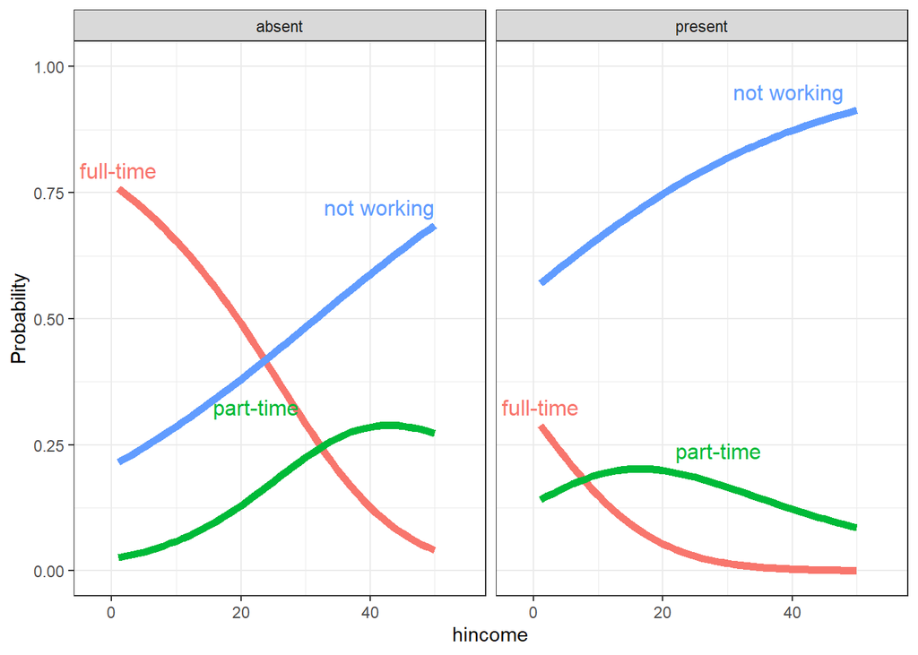

```r
gg <- ggplot(fit2,
             aes(x = hincome, y = Probability,
                 colour = Participation)) +
  facet_grid(~ children) +
  geom_line(size = 2) + theme_bw() +
  scale_x_continuous(limits = c(-3,55)) +
  scale_y_continuous(limits = c(0,1))
direct.label(gg, list("top.bumptwice", dl.trans(y = y + 0.2)))
```

`ggplot`을 통해 **남편의 수입**에 따른 **여성의 노동형태 확률**을 시각화하였고 **아이의 유무**에 따라 패널을 구분하였다.  
위의 그림은 `type = response`를 통해 확률을 예측한 모형이다.  
**partic = not working**인 여성은 `hincome`이 증가함에 따라 확률이 증가하는 것을 볼 수 있는데, 자녀가 있을 경우, 확률이 더 높은 것을 확인할 수 있다.  
반대로, **partic = full-time** 여성들은 `hincome`이 증가함에 따라 확률이 크게 감소하는 것을 살펴볼 수 있다.

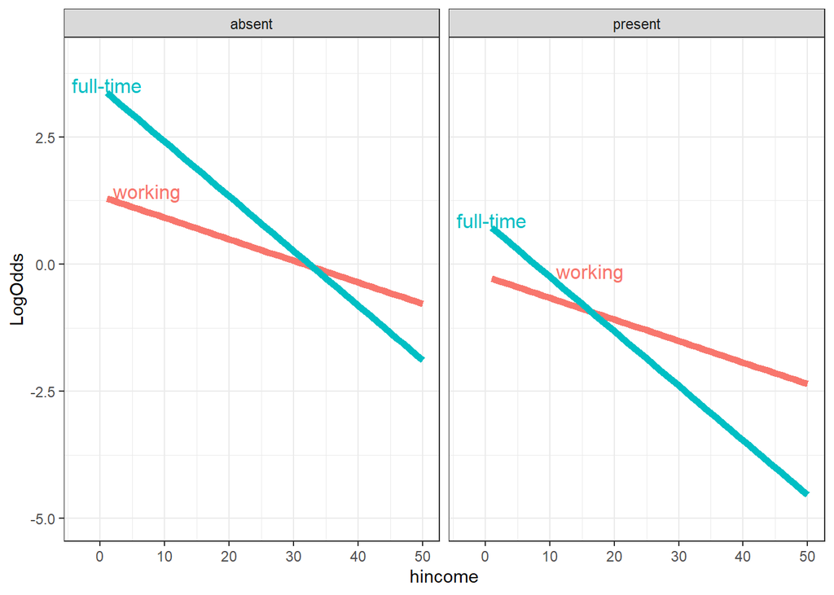

```r
fit3 <- melt(fit,
             measure.vars = c("l.working", "l.fulltime"),
             variable.name = "Participation",
             value.name = "LogOdds")
levels(fit3$Participation) <- c("working", "full-time")

gg <- ggplot(fit3,
             aes(x = hincome, y = LogOdds, colour = Participation)) +
  facet_grid(~ children) +
  geom_line(size = 2) + theme_bw() +
  scale_x_continuous(limits = c(-3,50)) +
  scale_y_continuous(limits = c(-5,4))
direct.label(gg, list("top.bumptwice", dl.trans(y = y + 0,2)))
```

`type = link`를 통해 예측한 모델의 결과에 대한 시각화를 진행해 보았다. 앞선 결과와 달리 직선의 형태를 가지는 것을 볼 수 있다.  
**partic = fulltime, wokring**모두 `hincome`변수가 증가함에 따라 **로그오즈**가 감소하는 것을 볼 수 있는데, **partic = fulltime**이 **partic = working**보다 더욱 빠르게 감소하는 것을 확인할 수 있다.

## 8.3 Generalized logit model

다중의 수준을 가지는 반응변수에 대한 가장 일반적인 접근법은 일반화된 로짓 모델이라고 불리는 **다항 로짓 모델(multinomial logit model)**을 사용하는 것이다. **일반화 로짓 (또는 다중 로짓)**이라 불리는 방법은 m개의 반응 범주 카테고리를 m-1개의 로짓의 집합으로 모델링한다.  
이를 통해, 첫 번째 범주를 기준으로 나머지 반응범주와 비교를 통해 모델을 적합시키고 해석한다.  
R에서는 `nnet`패키지의 `multinom`함수를 통해 사용할 수 있다.

`nnet`패키지는 단일 히든 레이어로 구성된 피드포워드 신경망 또는 다항 모델을 위한 함수들을 제공하는 패키지이다.  
`multinom`함수는 주어진 데이터에 대해서 **다항 로그 선형 모델**을 적합시키고자 할때 사용하는 함수이며, `nnet`패키지에 포함돼있다.  
- `multinom(, data)`

- formula: 분석가가 만들고자 하는 모델의 형태
- data: 모형에 적합할 데이터

*Example 8.2: Women’s labor force participation*

```r
levels(Womenlf$partic)
```

```
## [1] "fulltime" "not.work" "parttime"
```

```r
Womenlf$partic <- relevel(Womenlf$partic, ref = "not.work")
```

`womenlf`의 반응변수인 `partic`의 기준범주를 `relevel`을 통해 **not.work**변수로 재구성한다.  
`relevel`은 범주의 기준 범주 수준을 바꿔주는 함수이다.  
- `relevel(data,ref)`

- data: 범주의 수준을 재지정할 변수
- ref: 변수의 수준중 기준 범주 수준으로 바꿔줄 수준

```r
library(nnet)
wlf.multinom <- multinom(partic ~ hincome + children,
                         data = Womenlf, Hess = TRUE)
summary(wlf.multinom, Wald = TRUE)
```

```
## Call:
## multinom(formula = partic ~ hincome + children, data = Womenlf,
##     Hess = TRUE)
##
## Coefficients:
##          (Intercept)      hincome childrenpresent
## fulltime    1.982842 -0.097232073     -2.55860537
## parttime   -1.432321  0.006893838      0.02145558
##
## Std. Errors:
##          (Intercept)    hincome childrenpresent
## fulltime   0.4841789 0.02809599       0.3621999
## parttime   0.5924627 0.02345484       0.4690352
##
## Value/SE (Wald statistics):
##          (Intercept)    hincome childrenpresent
## fulltime    4.095266 -3.4607098     -7.06407045
## parttime   -2.417573  0.2939197      0.04574407
##
## Residual Deviance: 422.8819
## AIC: 434.8819
```

반응변수는 **partic**로 설정하고, **hincome, children**는 설명변수로 하는 다중 로짓모델을 적합시켜 보았다.  
**계수, 표준오차, 왈드 검정의 통계량**을 출력해주는 것을 확인할 수 있다.

```r
stats <- summary(wlf.multinom, Wald = TRUE)
z <- stats$Wald.ratios
p <- 2 * (1 - pnorm(abs(z)))
zapsmall(p)
```

```
##          (Intercept)   hincome childrenpresent
## fulltime   0.0000422 0.0005388       0.0000000
## parttime   0.0156244 0.7688193       0.9635142
```

```r
wlf.multinom2 <- multinom(partic ~ hincome * children,
                          data = Womenlf, Hess = TRUE)
Anova(wlf.multinom2)
```

```
## Analysis of Deviance Table (Type II tests)
##
## Response: partic
##                  LR Chisq Df Pr(>Chisq)
## hincome            15.153  2  0.0005123 ***
## children           63.559  2  1.579e-14 ***
## hincome:children    1.452  2  0.4837815
## ---
## Signif. codes:  0 '***' 0.001 '**' 0.01 '*' 0.05 '.' 0.1 ' ' 1
```

```r
predictors <- expand.grid(hincome = 1:50,
                          children = c("absent", "present"))
fit <- data.frame(predictors,
                  predict(wlf.multinom,predictors,type = "probs"))
```

`predict`함수를 통해 적합시킨 모델을 이용하여 새로운 데이터에 대한 예측을 진행해 보았다.  
`type = probs`를 통해 예측결과가 확률로써 출력되게 설정해주었다.

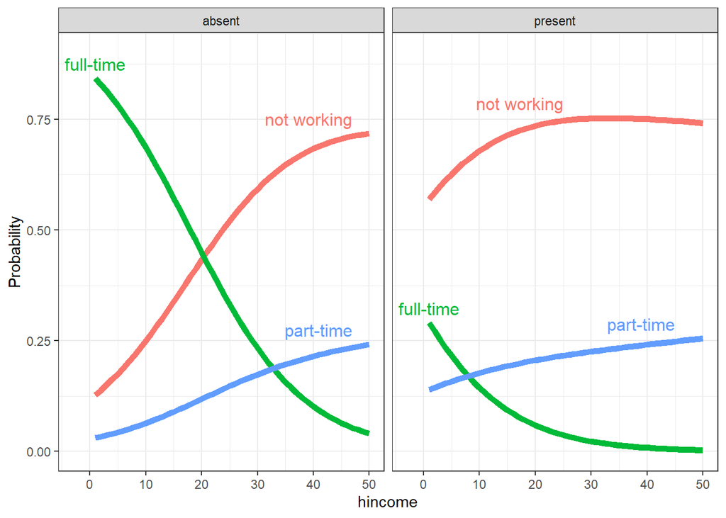

```r
fit2 <- melt(fit,
             measure.vars = c("not.work","fulltime","parttime"),
             variable.name = "Participation",
             value.name = "Probability")
levels(fit2$Participation) <- c("not working", "full-time", "part-time")

gg <- ggplot(fit2,
             aes(x = hincome, y = Probability, colour = Participation)) +
  facet_grid(~children) +
geom_line(size = 2) + theme_bw() +
  scale_x_continuous(limits = c(-3,50)) +
  scale_y_continuous(limits = c(0,0.9))
direct.label(gg, list("top.bumptwice", dl.trans(y = y + 0.2)))
```

예측된 결과에 대해 시각화를 진행해본 결과, 우리가 앞서 살펴본 **nested dichotomy models**의 결과와 거의 유사한 것을 살펴볼 수 있다.  
`hincome`이 증가함에 따라, **partic = full-time**의 확률은 점점 감소하고 **partic =not-working**의 확률은 증가한다.  
그러나, **일반화된 모델 로짓**은 **nested dichotomy models**과 다르게 **children = absent**인 경우, **hincome**이 증가함에 따라 **not-working**의 확률이 가파르게 증가하지만, **children = present`** 경우 완만하게 증가하다가 같은 확률로 수렴하는 것을 볼 수 있다.

```r
levels(Womenlf$partic)
```

```
## [1] "not.work" "fulltime" "parttime"
```

```r
Womenlf$partic <- ordered(Womenlf$partic,
                          levels = c("not.work","parttime","fulltime"))
wlf.multinom <- update(wlf.multinom, . ~ .)
```

`effect plot`을 통해서도 모델의 결과를 시각화 할 수 있다.  
단, 이때 반응 범주의 순서를 연구자가 분석하고자 하는 순서대로 반드시 정렬해 준 후, 모델을 적합시켜야 한다.

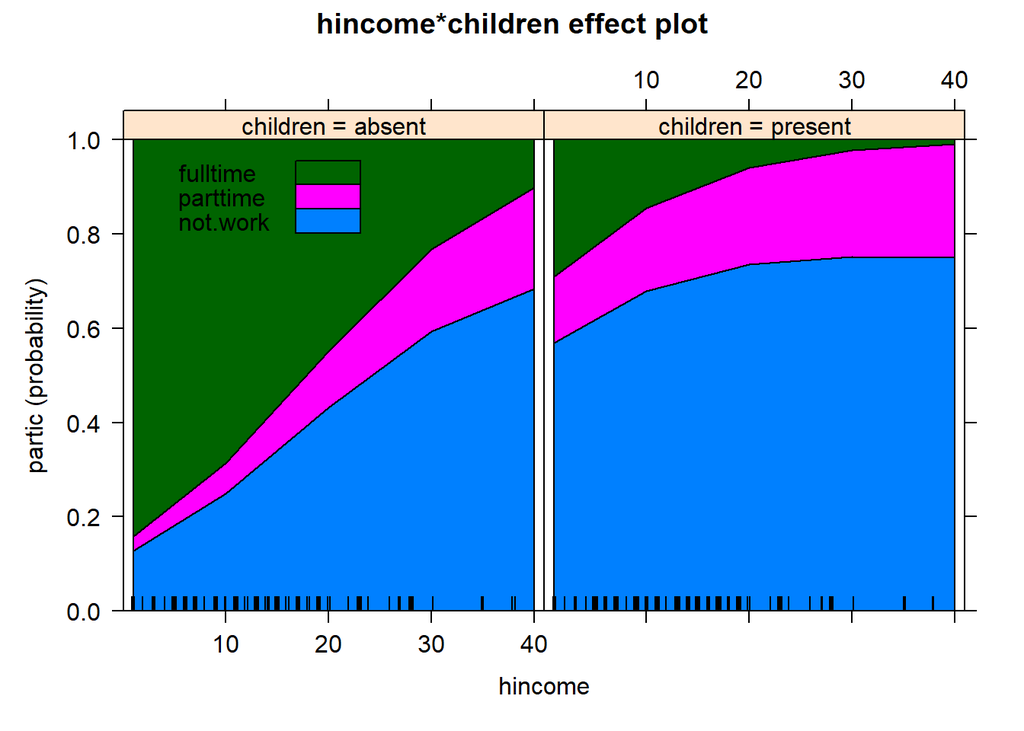

```r
plot(Effect(c("hincome", "children"), wlf.multinom),
     style = "stacked", key.args = list(x = 0.05, y = 0.9))
```

`Effect plot`을 통해서도, `hincome`이 증가함에 따라, **partic = fulltime**의 면적이 점점 작아지고(확률이 작아지고) **partic = notwork**의 면적이 점점 커지는 것(확률이 커지고)을 쉽게 살펴볼 수 있다.

**Summary of chapter8**

- 반응변수의 수준이 **binary**가 아닌 3개 이상 가지는 경우가 있을 수 있다. 이러한 경우, **Chapter7**에서 살펴본 모델과는 조금 다른 모델들을 사용해야한다.
- 특히, 반응변수의 수준이 많아지게 될때, 어떠한 수준을 기준으로 할것인지에 대해 고민하고 결정하는 것이 매우 중요하다.
- **Proportional odds model**은 각 설명변수들의 반응변수들에 대한 누적 로짓 확률이 같다고 가정(**proportional odds assumptions**)하여 적합시키는 모델로, 설명변수의 기울기가 각 반응변수의 수준에서 모두 같다. 반응변수가 다중 순서형 변수일때 유용하다.
- **partial proportional odds model**은 특정 부분 변수에는 **proportional odds assumptions**을 하여 기울기가 같게하고 나머지 부분 변수에 대해서는 **proportional odds assumptions**을 하지않아 기울기가 로그 누적 확률에 따라 변할 수 있게 적합시켜 주는 모델이다.
- 가장 일반적으로 사용되는 **다항 로짓모형**은 반응변수의 수준이 n개일때, 1개의 수준을 기준으로 정하고 n-1개의 반응변수에 대하여 설명변수를 이용하여 모형을 적합시키는 방법이다.
- 다중 반응변수를 통해 모델을 적합시키게 되면 모델의 파라미터가 많아지게 된다. 따라서, 이러한 경우 결과창을 시각화(예를 들어 `Effects`,`ggplot2`패키지를 활용)하여 요약된 결과를 살펴보는 것이 좋다.